# p8105_hw3_kp3127

2025-10-07

# Problem 1

```r
library(p8105.datasets)
data("instacart")
dim(instacart)
```

```
## [1] 1384617      15
```

```r
names(instacart)
```

```
##  [1] "order_id"               "product_id"             "add_to_cart_order"
##  [4] "reordered"              "user_id"                "eval_set"
##  [7] "order_number"           "order_dow"              "order_hour_of_day"
## [10] "days_since_prior_order" "product_name"           "aisle_id"
## [13] "department_id"          "aisle"                  "department"
```

Instacart is an online grocery service that allows you to shop online from local stores. In New York City, partner stores include Whole Foods, Fairway, and The Food Emporium. Instacart offers same-day delivery, and items that users purchase are delivered within 2 hours.  
The Instacart dataset contains 1384617 observations and 15 variables. Each row corresponds to a single product purchased within an order, and variables describe both the product and ordering details. For instance, key variables include:

`order_id` (unique order identifier)

`product_name` (name of the purchased item)

`aisle and department` (location and product category)

`order_dow` and `order_hour_of_day` (day of week and time of day when order was placed)

Example observations include items such as “Bulgarian Yogurt” from the “yogurt” aisle or “Organic Baby Spinach” from the “fresh vegetables” aisle. This dataset provides a rich source for exploring consumer purchasing patterns across different times, aisles, and departments.

```r
instacart_sum <- instacart %>%
  count(aisle_id, aisle, sort = TRUE)
```

```r
instacart_sum %>%
  filter(n>10000) %>%
  mutate(aisle = fct_reorder(aisle, n))
```

```
## # A tibble: 39 × 3
##    aisle_id aisle                              n
##       <int> <fct>                          <int>
##  1       83 fresh vegetables              150609
##  2       24 fresh fruits                  150473
##  3      123 packaged vegetables fruits     78493
##  4      120 yogurt                         55240
##  5       21 packaged cheese                41699
##  6      115 water seltzer sparkling water  36617
##  7       84 milk                           32644
##  8      107 chips pretzels                 31269
##  9       91 soy lactosefree                26240
## 10      112 bread                          23635
## # ℹ 29 more rows
```

[figure not shown]

```r
instacart_sum |>
  ggplot(aes(x = aisle_id, y = n)) +
  geom_point() +
  labs(
    title = "Number of items ordered by aisle (more than 10,000 orders)",
    x = "Aisle_id",
    y = "Number of items ordered"
  ) +
  theme_minimal()
```

```r
popular_items = instacart %>%
  filter(aisle %in% c("baking ingredients", "dog food care", "packaged vegetables fruits")) %>%
  group_by(aisle, product_name) %>%
  summarise(n_orders = n()) %>%
  arrange(aisle, desc(n_orders)) %>%
  filter(min_rank(desc(n_orders))<4)
popular_items
```

```
## # A tibble: 9 × 3
## # Groups:   aisle [3]
##   aisle                      product_name                               n_orders
##   <chr>                      <chr>                                         <int>
## 1 baking ingredients         Light Brown Sugar                               499
## 2 baking ingredients         Pure Baking Soda                                387
## 3 baking ingredients         Cane Sugar                                      336
## 4 dog food care              Snack Sticks Chicken & Rice Recipe Dog Tr…       30
## 5 dog food care              Organix Chicken & Brown Rice Recipe              28
## 6 dog food care              Small Dog Biscuits                               26
## 7 packaged vegetables fruits Organic Baby Spinach                           9784
## 8 packaged vegetables fruits Organic Raspberries                            5546
## 9 packaged vegetables fruits Organic Blueberries                            4966
```

```r
mean_table <- instacart %>%
  filter(product_name %in% c("Pink Lady Apples", "Coffee Ice Cream")) %>%
  group_by(product_name, order_dow) %>%
  summarise(mean_hr=mean(order_hour_of_day, na.rm=TRUE)) %>%
  mutate(order_dow = recode(order_dow,
                            `0` = "Sun", `1` = "Mon", `2` = "Tue", `3` = "Wed",
                            `4` = "Thu", `5` = "Fri", `6` = "Sat")) %>%
  pivot_wider(
    names_from = order_dow,
    values_from = mean_hr
  )
knitr::kable(
  mean_table,
  caption = "the mean hour of the day of Pink Lady Apples and Coffee Ice Cream ;"
)
```

the mean hour of the day of Pink Lady Apples and Coffee Ice Cream ;

| product_name | Sun | Mon | Tue | Wed | Thu | Fri | Sat |
| --- | --- | --- | --- | --- | --- | --- | --- |
| Coffee Ice Cream | 13.77419 | 14.31579 | 15.38095 | 15.31818 | 15.21739 | 12.26316 | 13.83333 |
| Pink Lady Apples | 13.44118 | 11.36000 | 11.70213 | 14.25000 | 11.55172 | 12.78431 | 11.93750 |

# Problem 2

```r
zip_code=read.csv("./zillow_data/Zip Codes.csv") %>%
  janitor::clean_names() %>%
  mutate(
    zip=as.character(zip_code)
  ) %>%
  select(zip,county,neighborhood) %>%
  arrange(zip)

zori_nyc=read.csv("./zillow_data/Zip_zori_uc_sfrcondomfr_sm_month_NYC.csv") %>%
  janitor::clean_names() %>%
  pivot_longer(
    cols = 10:last_col(),
    names_to = "date",
    values_to = "rent_index"
  ) %>%
  mutate(
    zip=as.character(region_name),
    date=str_remove(date,"^x"),
    date=ymd(str_replace_all(date,"_","-"))
  ) %>%
  select(zip,date,rent_index) %>%
  drop_na(rent_index) %>%
  arrange(zip)
```

```r
zori_obs <- zori_nyc %>%
  group_by(zip) %>%
  summarise(n_obs=n())

n_full <- zori_obs %>%
  filter(n_obs == 116) %>%
  nrow()

n_sparse <- zori_obs %>%
  filter(n_obs < 10) %>%
  nrow()
```

There are 48 ZIP codes observed in all 116 months, and 26 ZIP codes observed fewer than 10 times.  
Why are some ZIP codes are observed rarely and others observed in each month?  
Some ZIP codes appear rarely in the Zillow dataset because Zillow only reports a rent index when there are enough active rental listings to produce a reliable median estimate.

```r
zipmap_dups <- zip_code %>% count(zip) %>% filter(n > 1)
zipmap_dups
```

```
##     zip n
## 1 10463 2
## 2 11201 2
```

```r
zip_code <- zip_code %>%
  mutate(
    county = case_when(
      zip == "10463" ~ "Bronx",
      zip == "11201" ~ "Kings",
      TRUE ~ county
    )
  ) %>%
  distinct(zip, .keep_all = TRUE)
zori_final <- zori_nyc %>%
  left_join(zip_code, by = "zip") %>%
  arrange(zip, date)
```

```r
zori_table <- zori_final %>%
  mutate(year=year(date)) %>%
  group_by(county,year) %>%
  summarise(
    mean_rent = mean(rent_index, na.rm = TRUE)
  ) %>%
  pivot_wider(
    names_from = year,
    values_from = mean_rent
  )
knitr::kable(
  zori_table,
  caption = "the average rental price in each borough and year"
)
```

the average rental price in each borough and year

| county | 2015 | 2016 | 2017 | 2018 | 2019 | 2020 | 2021 | 2022 | 2023 | 2024 |
| --- | --- | --- | --- | --- | --- | --- | --- | --- | --- | --- |
| Bronx | 1759.595 | 1520.194 | 1543.599 | 1639.430 | 1705.589 | 1811.443 | 1857.777 | 2054.267 | 2285.459 | 2496.896 |
| Kings | 2492.928 | 2520.357 | 2545.828 | 2547.291 | 2630.504 | 2555.051 | 2549.890 | 2868.199 | 3015.184 | 3125.657 |
| New York | 3022.042 | 3038.818 | 3133.848 | 3183.703 | 3310.408 | 3106.517 | 3136.632 | 3778.375 | 3932.610 | 4078.440 |
| Queens | 2214.707 | 2271.955 | 2263.303 | 2291.918 | 2387.816 | 2315.632 | 2210.787 | 2406.038 | 2561.615 | 2693.584 |
| Richmond | NA | NA | NA | NA | NA | 1977.608 | 2045.430 | 2147.436 | 2332.934 | 2536.442 |

```r
zori_zip_year <- zori_final %>%
  mutate(
        year=year(date),
    borough = case_match(
      county,
      "Bronx" ~ "Bronx",
      "Kings" ~ "Brooklyn",
      "New York" ~ "Manhattan",
      "Queens" ~ "Queens",
      "Richmond" ~ "Staten Island",
      .default = NA_character_
         )
  ) %>%
  group_by(borough,year) %>%
  summarise(mean_rent = mean(rent_index, na.rm = TRUE))
```

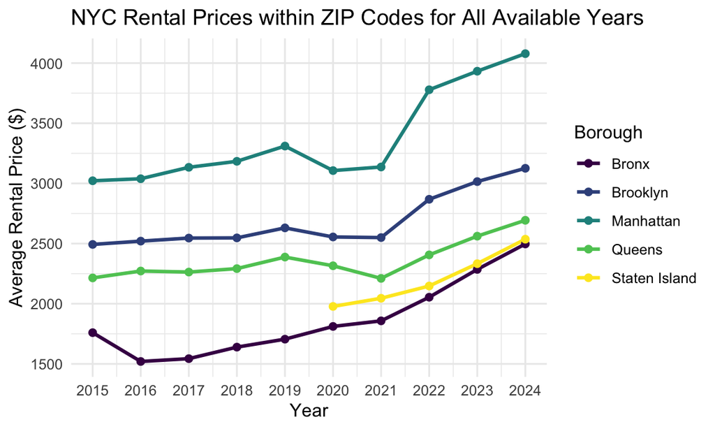

```r
zori_line <-
  ggplot(zori_zip_year, aes(x = year, y = mean_rent, color = borough)) +
  geom_line(linewidth = 1) +
  geom_point(size = 1.8) +
  labs(
    title = "NYC Rental Prices within ZIP Codes for All Available Years",
    x = "Year",
    y = "Average Rental Price ($)",
    color = "Borough"
  ) +
  scale_x_continuous(
    breaks = seq(min(zori_zip_year$year, na.rm = TRUE),
                 max(zori_zip_year$year, na.rm = TRUE),
                 by = 1)
  ) +
  theme_minimal()
zori_line
```

Rental prices increased steadily across all five NYC boroughs between 2015 and 2024, with a noticeable dip around 2020–2021 followed by a sharp post-pandemic rebound.  
Manhattan remains the most expensive borough, with average rents rising from just over $3,000 in 2015 to above $4,000 by 2024.  
Brooklyn and Queens show consistent growth and now exceed $3,000 and $2,600 respectively.  
The Bronx is still the most affordable area but experienced the fastest proportional increase, rising from roughly $1,700 to about $2,500.  
Staten Island appears in the dataset later (around 2020) and follows a similar upward trend.

```r
zori_23 <- zori_final %>%
  mutate(
        year=year(date),
    borough = case_match(
      county,
      "Bronx" ~ "Bronx",
      "Kings" ~ "Brooklyn",
      "New York" ~ "Manhattan",
      "Queens" ~ "Queens",
      "Richmond" ~ "Staten Island",
      .default = NA_character_
         )
  ) %>%
  filter(year == 2023, !is.na(borough)) %>%
  group_by(borough, zip) %>%
  summarise(mean_rent23 = mean(rent_index, na.rm = TRUE))
```

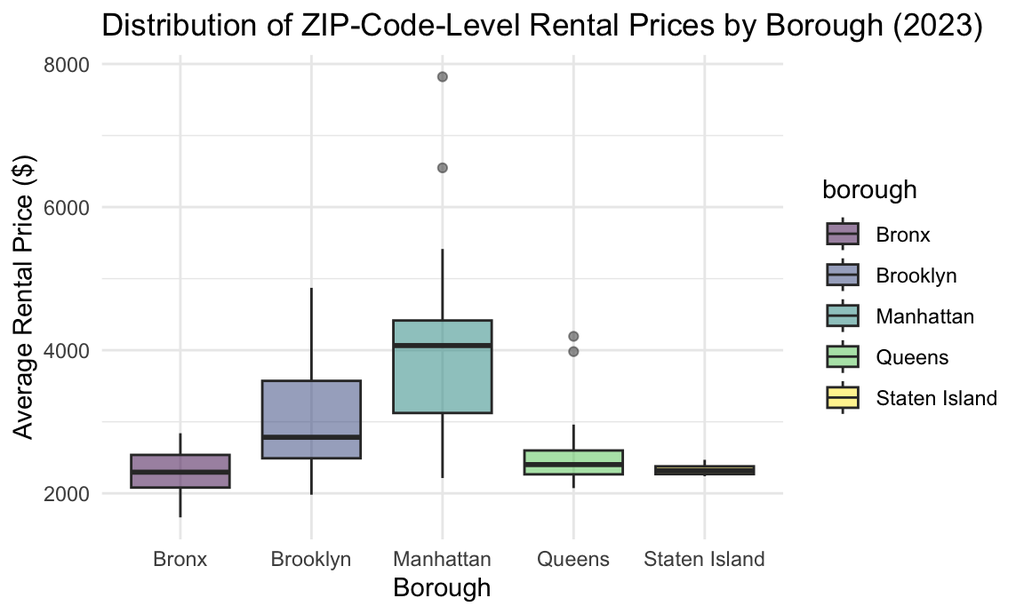

```r
zori_box <-
ggplot(zori_23, aes(x = borough, y = mean_rent23, fill = borough)) +
  geom_boxplot(alpha = 0.5) +
  labs(
    title = "Distribution of ZIP-Code-Level Rental Prices by Borough (2023)",
    x = "Borough",
    y = "Average Rental Price ($)"
  ) +
  theme_minimal()
zori_box
```

combine and save

```r
combined_plot <- zori_line / zori_box +
  plot_annotation(title = "NYC Rental Price Trends and 2023 Distributions")

ggsave("nyc_rental_combined.png", combined_plot, width = 12, height = 8, dpi = 300)
```